# Nicfall_originalhwcode_02

Nicola Kriefall

9/26/2019

# Notes on the hw subject

## Poisson Distribution

The Poisson Distribution is often used to model open ended counts of independently occuring events, for example the number of cars that pass a traffic intersection over a given interval of time or the number of times a monkey scratches itself during a given observation interval. The probability mass function for the Poisson distribution is described by a single parameter, λ, where λ can be interpreted as the mean number of occurrences of the event in the given interval.

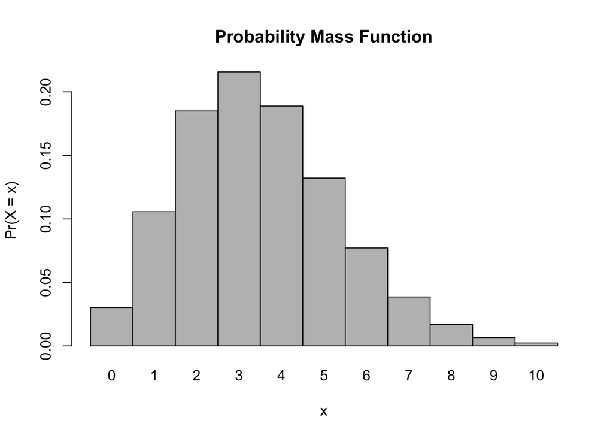

```r
x <- 0:10
l = 3.5
probset<-dpois(x=x,lambda=l)
barplot(probset,names.arg=x,space=0,xlab="x",ylab="Pr(X = x)",main="Probability Mass Function")
```

Cumulative function distribution:

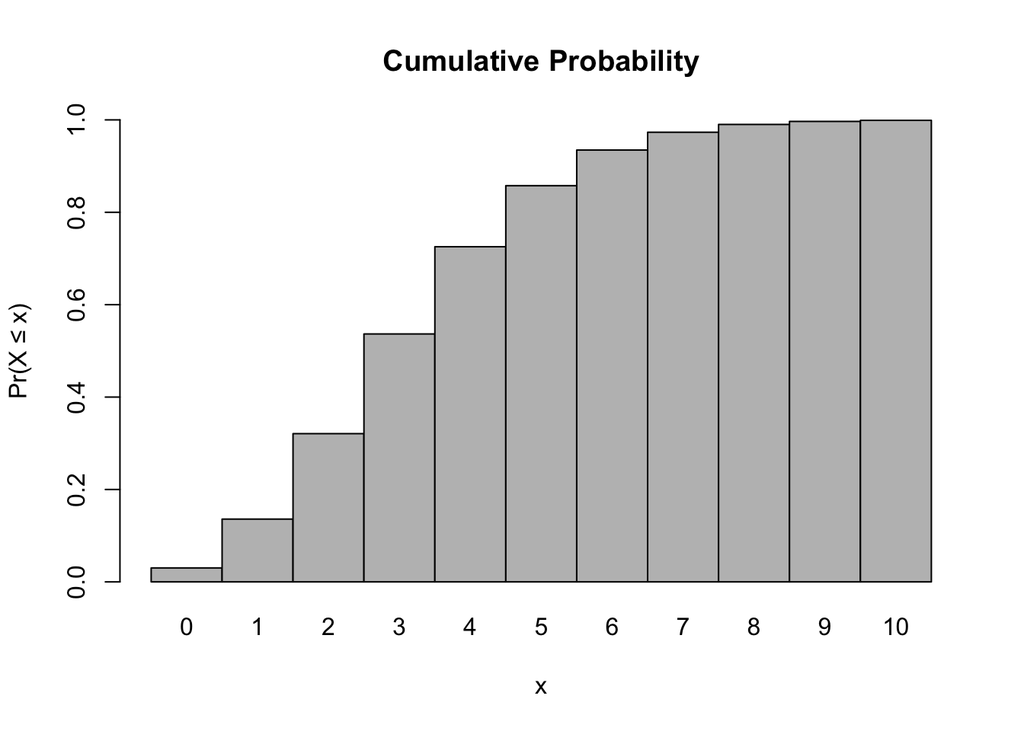

```r
x <- 0:10
l <- 3.5
barplot(ppois(q=x,lambda=l),ylim=0:1,space=0, names.arg=x,xlab="x",ylab="Pr(X ≤ x)",main="Cumulative Probability")
```